# Homework 1

Yuqi Wang

9/14/2020

This is my solution to Homework 1.

```r
library(tidyverse)
```

## Problem 1

Create a data frame with the specified elements.

```r
problem1_df <- tibble(
  random_num = rnorm(n = 10),
  logic_vec = random_num > 0,
  char_vec = c("a", "b", "c", "d", "e", "f", "g", "h", "i", "j"),
  factor_vec = factor(c("low", "low", "low", "mid", "mid", "mid", "high", "high", "high", "low"))
)

problem1_df
```

```
## # A tibble: 10 x 4
##    random_num logic_vec char_vec factor_vec
##         <dbl> <lgl>     <chr>    <fct>
##  1     -1.06  FALSE     a        low
##  2      0.113 TRUE      b        low
##  3     -1.33  FALSE     c        low
##  4     -0.132 FALSE     d        mid
##  5     -0.186 FALSE     e        mid
##  6     -0.574 FALSE     f        mid
##  7     -0.944 FALSE     g        high
##  8     -1.71  FALSE     h        high
##  9      1.04  TRUE      i        high
## 10      0.893 TRUE      j        low
```

Next, we take the mean of the four columns in the data frame.

```r
mean(pull(problem1_df, random_num))
```

```
## [1] -0.3884212
```

```r
mean(pull(problem1_df, logic_vec))
```

```
## [1] 0.3
```

```r
mean(pull(problem1_df, char_vec))
```

```
## [1] NA
```

```r
mean(pull(problem1_df, factor_vec))
```

```
## [1] NA
```

The results of the mean function shows that the mean of numeric variable and logic vector can be calculated, while character vector and factor vector do not work.

Using `as.numeric` function to convert variable type:

```r
as.numeric(pull(problem1_df, random_num))
as.numeric(pull(problem1_df, logic_vec))
as.numeric(pull(problem1_df, char_vec))
as.numeric(pull(problem1_df, factor_vec))
```

[output not shown]

The result of `as.numeric` shows that logical vector and factor vector can be converted to numeric variables, while character vector can not been converted. This helps to explain that we can take the mean of the logical vector, but for factor vector, we can not calculate the mean because factor represents categories, and taking the mean for categories is not meaningful.

The following are the calculations for variable type conversion and the product with the random sample:

```r
as.numeric(pull(problem1_df, logic_vec)) * pull(problem1_df, random_num)
```

```
##  [1] 0.0000000 0.1125855 0.0000000 0.0000000 0.0000000 0.0000000 0.0000000
##  [8] 0.0000000 1.0373730 0.8928257
```

```r
as.factor(pull(problem1_df, logic_vec)) * pull(problem1_df, random_num)
```

```
##  [1] NA NA NA NA NA NA NA NA NA NA
```

```r
as.numeric(as.factor(pull(problem1_df, logic_vec))) * pull(problem1_df, random_num)
```

```
##  [1] -1.0562137  0.2251710 -1.3293530 -0.1316118 -0.1860007 -0.5739869
##  [7] -0.9438599 -1.7059697  2.0747460  1.7856515
```

The result shows that factor vector cannot be used for calculation.

## Problem 2

```r
data("penguins", package = "palmerpenguins")
```

Description of the `penguins` dataset:

- The `penguins` data set collected data for penguins of the following species: Adelie, Gentoo, Chinstrap. These penguins were from Torgersen, Biscoe, Dream and the data was collected in year 2007, 2008, 2009. The data set contains variables including bill_depth_mm, bill_length_mm, body_mass_g, flipper_length_mm, island, sex, species, year.
  - The maximum of bill length is 59.6 mm, the minimum of bill length is 32.1 mm, and the mean is 43.9219298 mm.
  - The maximum of bill depth is 21.5 mm, the minimum of bill depth is 13.1 mm, and the mean is 17.1511696 mm.
  - The maximum of flipper length is 231 mm, the minimum of bill depth is 172 mm.
  - The maximum of body mass is 6300 g, the minimum of bill depth is 2700 g, and the mean is 4201.754386 g.
  - The numbers of female, male and sex-unspecified penguins are 165, 168, 11.
- The `penguins` data set includes 8 variables to describe the characteristics for 344 observations.
- The mean flipper length is 200.92 mm.

#### Scatterplot

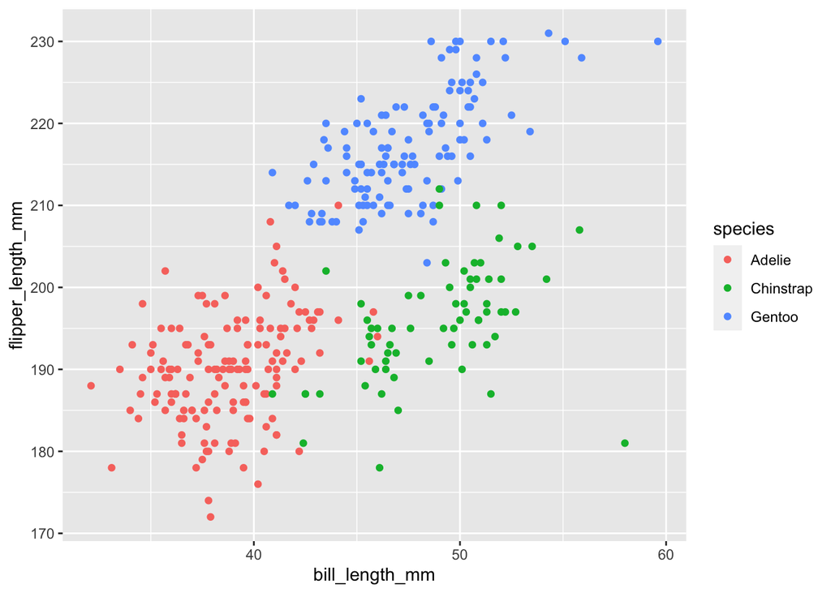

```r
# build the scatterplot between bill length and flipper length
ggplot(penguins, aes(x = bill_length_mm, y = flipper_length_mm, color = species)) + geom_point()
```

```r
# save the plot to the project directory
ggsave("penguin.pdf", height = 5, width = 5)
```